# EasyVisa Project

## Context:

Business communities in the United States are facing high demand for human resources, but one of the constant challenges is identifying and attracting the right talent, which is perhaps the most important element in remaining competitive. Companies in the United States look for hard-working, talented, and qualified individuals both locally as well as abroad.

The Immigration and Nationality Act (INA) of the US permits foreign workers to come to the United States to work on either a temporary or permanent basis. The act also protects US workers against adverse impacts on their wages or working conditions by ensuring US employers' compliance with statutory requirements when they hire foreign workers to fill workforce shortages. The immigration programs are administered by the Office of Foreign Labor Certification (OFLC).

OFLC processes job certification applications for employers seeking to bring foreign workers into the United States and grants certifications in those cases where employers can demonstrate that there are not sufficient US workers available to perform the work at wages that meet or exceed the wage paid for the occupation in the area of intended employment.

## Objective:

In FY 2016, the OFLC processed 775,979 employer applications for 1,699,957 positions for temporary and permanent labor certifications. This was a nine percent increase in the overall number of processed applications from the previous year. The process of reviewing every case is becoming a tedious task as the number of applicants is increasing every year.

The increasing number of applicants every year calls for a Machine Learning based solution that can help in shortlisting the candidates having higher chances of VISA approval. OFLC has hired your firm EasyVisa for data-driven solutions. You as a data scientist have to analyze the data provided and, with the help of a classification model:

- Facilitate the process of visa approvals.
- Recommend a suitable profile for the applicants for whom the visa should be certified or denied based on the drivers that significantly influence the case status.

## Data Description

The data contains the different attributes of the employee and the employer. The detailed data dictionary is given below.

- case_id: ID of each visa application
- continent: Information of continent the employee
- education_of_employee: Information of education of the employee
- has_job_experience: Does the employee has any job experience? Y= Yes; N = No
- requires_job_training: Does the employee require any job training? Y = Yes; N = No
- no_of_employees: Number of employees in the employer's company
- yr_of_estab: Year in which the employer's company was established
- region_of_employment: Information of foreign worker's intended region of employment in the US.
- prevailing_wage: Average wage paid to similarly employed workers in a specific occupation in the area of intended employment. The purpose of the prevailing wage is to ensure that the foreign worker is not underpaid compared to other workers offering the same or similar service in the same area of employment.
- unit_of_wage: Unit of prevailing wage. Values include Hourly, Weekly, Monthly, and Yearly.
- full_time_position: Is the position of work full-time? Y = Full Time Position; N = Part Time Position
- case_status: Flag indicating if the Visa was certified or denied

## Importing necessary libraries and data

```python
import pandas as pd
import numpy as np
from sklearn import metrics
import matplotlib.pyplot as plt
%matplotlib inline
import warnings
warnings.filterwarnings('ignore')
import seaborn as sns
from sklearn.model_selection import train_test_split
from sklearn.model_selection import GridSearchCV
from sklearn import metrics

# boosting specific libraries
from sklearn.tree import DecisionTreeClassifier
from sklearn.ensemble import AdaBoostClassifier, GradientBoostingClassifier

# bagging specific libraries
from sklearn.ensemble import BaggingClassifier, RandomForestClassifier
from sklearn.linear_model import LogisticRegression

from sklearn.tree import DecisionTreeRegressor
from sklearn.ensemble import BaggingRegressor,RandomForestRegressor, GradientBoostingRegressor, AdaBoostRegressor, StackingRegressor
from sklearn import metrics
from sklearn.model_selection import GridSearchCV, train_test_split
```

## Data Overview

- Observations
- Sanity checks

```python
#Loading dataset
EasyVisa=pd.read_csv("EasyVisa.csv")
data = EasyVisa.copy()
```

```python
#View the first 5 rows of the dataset.
data.head()
```

|  | case_id | continent | education_of_employee | has_job_experience | requires_job_training | no_of_employees | yr_of_estab | region_of_employment | prevailing_wage | unit_of_wage | full_time_position | case_status |
| --- | --- | --- | --- | --- | --- | --- | --- | --- | --- | --- | --- | --- |
| 0 | EZYV01 | Asia | High School | N | N | 14513 | 2007 | West | 592.2029 | Hour | Y | Denied |
| 1 | EZYV02 | Asia | Master's | Y | N | 2412 | 2002 | Northeast | 83425.6500 | Year | Y | Certified |
| 2 | EZYV03 | Asia | Bachelor's | N | Y | 44444 | 2008 | West | 122996.8600 | Year | Y | Denied |
| 3 | EZYV04 | Asia | Bachelor's | N | N | 98 | 1897 | West | 83434.0300 | Year | Y | Denied |
| 4 | EZYV05 | Africa | Master's | Y | N | 1082 | 2005 | South | 149907.3900 | Year | Y | Certified |

```python
#View the last 5 rows of the dataset
data.tail()
```

|  | case_id | continent | education_of_employee | has_job_experience | requires_job_training | no_of_employees | yr_of_estab | region_of_employment | prevailing_wage | unit_of_wage | full_time_position | case_status |
| --- | --- | --- | --- | --- | --- | --- | --- | --- | --- | --- | --- | --- |
| 25475 | EZYV25476 | Asia | Bachelor's | Y | Y | 2601 | 2008 | South | 77092.57 | Year | Y | Certified |
| 25476 | EZYV25477 | Asia | High School | Y | N | 3274 | 2006 | Northeast | 279174.79 | Year | Y | Certified |
| 25477 | EZYV25478 | Asia | Master's | Y | N | 1121 | 1910 | South | 146298.85 | Year | N | Certified |
| 25478 | EZYV25479 | Asia | Master's | Y | Y | 1918 | 1887 | West | 86154.77 | Year | Y | Certified |
| 25479 | EZYV25480 | Asia | Bachelor's | Y | N | 3195 | 1960 | Midwest | 70876.91 | Year | Y | Certified |

```python
#Check data types and number of non-null values for each column.
data.info()
```

```
<class 'pandas.core.frame.DataFrame'>
RangeIndex: 25480 entries, 0 to 25479
Data columns (total 12 columns):
 #   Column                 Non-Null Count  Dtype
---  ------                 --------------  -----
 0   case_id                25480 non-null  object
 1   continent              25480 non-null  object
 2   education_of_employee  25480 non-null  object
 3   has_job_experience     25480 non-null  object
 4   requires_job_training  25480 non-null  object
 5   no_of_employees        25480 non-null  int64
 6   yr_of_estab            25480 non-null  int64
 7   region_of_employment   25480 non-null  object
 8   prevailing_wage        25480 non-null  float64
 9   unit_of_wage           25480 non-null  object
 10  full_time_position     25480 non-null  object
 11  case_status            25480 non-null  object
dtypes: float64(1), int64(2), object(9)
memory usage: 2.3+ MB
```

```python
data.isna().sum()
```

```
case_id                  0
continent                0
education_of_employee    0
has_job_experience       0
requires_job_training    0
no_of_employees          0
yr_of_estab              0
region_of_employment     0
prevailing_wage          0
unit_of_wage             0
full_time_position       0
case_status              0
dtype: int64
```

- There are no missing values in the data.

```python
# Summary of continuous column
data[['prevailing_wage']].describe().T
```

|  | count | mean | std | min | 25% | 50% | 75% | max |
| --- | --- | --- | --- | --- | --- | --- | --- | --- |
| prevailing_wage | 25480.0 | 74455.814592 | 52815.942327 | 2.1367 | 34015.48 | 70308.21 | 107735.5125 | 319210.27 |

```python
data.describe()
```

|  | no_of_employees | yr_of_estab | prevailing_wage |
| --- | --- | --- | --- |
| count | 25480.000000 | 25480.000000 | 25480.000000 |
| mean | 5667.043210 | 1979.409929 | 74455.814592 |
| std | 22877.928848 | 42.366929 | 52815.942327 |
| min | -26.000000 | 1800.000000 | 2.136700 |
| 25% | 1022.000000 | 1976.000000 | 34015.480000 |
| 50% | 2109.000000 | 1997.000000 | 70308.210000 |
| 75% | 3504.000000 | 2005.000000 | 107735.512500 |
| max | 602069.000000 | 2016.000000 | 319210.270000 |

```python
#Number of unique values in each column
data.nunique()
```

```
case_id                  25480
continent                    6
education_of_employee        4
has_job_experience           2
requires_job_training        2
no_of_employees           7105
yr_of_estab                199
region_of_employment         5
prevailing_wage          25454
unit_of_wage                 4
full_time_position           2
case_status                  2
dtype: int64
```

```python
# we can drop case id, as this will not add value to the dataset
data.drop(columns=['case_id'], inplace=True)
```

```python
#Number of observations
cat_cols=['yr_of_estab']

for column in cat_cols:
    print(data[column].value_counts())
    print('-'*30)
```

```
1998    1134
2005    1051
2001    1017
2007     994
1999     870
        ...
1820       6
1846       4
1822       4
1810       3
1824       2
Name: yr_of_estab, Length: 199, dtype: int64
------------------------------
```

### Data Preprocessing

```python
#Number of observations in columns with a few unique values
cat_cols=['continent', 'education_of_employee', 'has_job_experience', 'requires_job_training', 'region_of_employment', 'unit_of_wage', 'full_time_position', 'case_status']

for column in cat_cols:
    print(data[column].value_counts())
```

```
Asia             16861
Europe            3732
North America     3292
South America      852
Africa             551
Oceania            192
Name: continent, dtype: int64
Bachelor's     10234
Master's        9634
High School     3420
Doctorate       2192
Name: education_of_employee, dtype: int64
Y    14802
N    10678
Name: has_job_experience, dtype: int64
N    22525
Y     2955
Name: requires_job_training, dtype: int64
Northeast    7195
South        7017
West         6586
Midwest      4307
Island        375
Name: region_of_employment, dtype: int64
Year     22962
Hour      2157
Week       272
Month       89
Name: unit_of_wage, dtype: int64
Y    22773
N     2707
Name: full_time_position, dtype: int64
Certified    17018
Denied        8462
Name: case_status, dtype: int64
```

```python
replaceStruct = {
                "continent":     {"Asia": 1, "Europe": 2 ,"North America": 3 ,"South America": 4, "Africa": 5, "Oceania": 6},
                "has_job_experience": {"N": 1, "Y": 2},
                 "requires_job_training": {"N": 1, "Y": 2},
                 "region_of_employment":     {"Northeast": 1, "South": 2 ,"West": 3 ,"Midwest": 4 ,"Island": 5},
                "unit_of_wage":     {"Hour": 1, "Week": 2, "Month": 3, "Year": 4},
                "full_time_position":     {"N": 1, "Y": 2 },
                "case_status":     {"Denied": 0, "Certified": 1 }
                    }
oneHotCols=["education_of_employee"]
```

```python
data=data.replace(replaceStruct)
data=pd.get_dummies(data, columns=oneHotCols)
```

### EDA

```python
data.head(10)
```

|  | continent | has_job_experience | requires_job_training | no_of_employees | yr_of_estab | region_of_employment | prevailing_wage | unit_of_wage | full_time_position | case_status | education_of_employee_Bachelor's | education_of_employee_Doctorate | education_of_employee_High School | education_of_employee_Master's |
| --- | --- | --- | --- | --- | --- | --- | --- | --- | --- | --- | --- | --- | --- | --- |
| 0 | 1 | 1 | 1 | 14513 | 2007 | 3 | 592.2029 | 1 | 2 | 0 | 0 | 0 | 1 | 0 |
| 1 | 1 | 2 | 1 | 2412 | 2002 | 1 | 83425.6500 | 4 | 2 | 1 | 0 | 0 | 0 | 1 |
| 2 | 1 | 1 | 2 | 44444 | 2008 | 3 | 122996.8600 | 4 | 2 | 0 | 1 | 0 | 0 | 0 |
| 3 | 1 | 1 | 1 | 98 | 1897 | 3 | 83434.0300 | 4 | 2 | 0 | 1 | 0 | 0 | 0 |
| 4 | 5 | 2 | 1 | 1082 | 2005 | 2 | 149907.3900 | 4 | 2 | 1 | 0 | 0 | 0 | 1 |
| 5 | 1 | 2 | 1 | 2339 | 2012 | 2 | 78252.1400 | 4 | 2 | 1 | 0 | 0 | 0 | 1 |
| 6 | 1 | 1 | 1 | 4985 | 1994 | 2 | 53635.3900 | 4 | 2 | 1 | 1 | 0 | 0 | 0 |
| 7 | 3 | 2 | 1 | 3035 | 1924 | 3 | 418.2298 | 1 | 2 | 0 | 1 | 0 | 0 | 0 |
| 8 | 1 | 1 | 1 | 4810 | 2012 | 4 | 74362.1900 | 4 | 2 | 1 | 1 | 0 | 0 | 0 |
| 9 | 2 | 2 | 1 | 2251 | 1995 | 2 | 67514.7600 | 4 | 2 | 1 | 0 | 1 | 0 | 0 |

```python
data.info()
```

```
<class 'pandas.core.frame.DataFrame'>
RangeIndex: 25480 entries, 0 to 25479
Data columns (total 14 columns):
 #   Column                             Non-Null Count  Dtype
---  ------                             --------------  -----
 0   continent                          25480 non-null  int64
 1   has_job_experience                 25480 non-null  int64
 2   requires_job_training              25480 non-null  int64
 3   no_of_employees                    25480 non-null  int64
 4   yr_of_estab                        25480 non-null  int64
 5   region_of_employment               25480 non-null  int64
 6   prevailing_wage                    25480 non-null  float64
 7   unit_of_wage                       25480 non-null  int64
 8   full_time_position                 25480 non-null  int64
 9   case_status                        25480 non-null  int64
 10  education_of_employee_Bachelor's   25480 non-null  uint8
 11  education_of_employee_Doctorate    25480 non-null  uint8
 12  education_of_employee_High School  25480 non-null  uint8
 13  education_of_employee_Master's     25480 non-null  uint8
dtypes: float64(1), int64(9), uint8(4)
memory usage: 2.0 MB
```

## Exploratory Data Analysis (EDA)

- EDA is an important part of any project involving data.
- It is important to investigate and understand the data better before building a model with it.
- A few questions have been mentioned below which will help you approach the analysis in the right manner and generate insights from the data.
- A thorough analysis of the data, in addition to the questions mentioned below, should be done.

### Univariate analysis

```python
# function to plot a boxplot and a histogram along the same scale.


def histogram_boxplot(data, feature, figsize=(12, 7), kde=False, bins=None):
    """
    Boxplot and histogram combined

    data: dataframe
    feature: dataframe column
    figsize: size of figure (default (12,7))
    kde: whether to show the density curve (default False)
    bins: number of bins for histogram (default None)
    """
    f2, (ax_box2, ax_hist2) = plt.subplots(
        nrows=2,  # Number of rows of the subplot grid= 2
        sharex=True,  # x-axis will be shared among all subplots
        gridspec_kw={"height_ratios": (0.25, 0.75)},
        figsize=figsize,
    )  # creating the 2 subplots
    sns.boxplot(
        data=data, x=feature, ax=ax_box2, showmeans=True, color="violet"
    )  # boxplot will be created and a star will indicate the mean value of the column
    sns.histplot(
        data=data, x=feature, kde=kde, ax=ax_hist2, bins=bins, palette="winter"
    ) if bins else sns.histplot(
        data=data, x=feature, kde=kde, ax=ax_hist2
    )  # For histogram
    ax_hist2.axvline(
        data[feature].mean(), color="green", linestyle="--"
    )  # Add mean to the histogram
    ax_hist2.axvline(
        data[feature].median(), color="black", linestyle="-"
    )  # Add median to the histogram
```

**Leading Questions**:

1. Those with higher education may want to travel abroad for a well-paid job. Does education play a role in Visa certification?
2. How does the visa status vary across different continents?
3. Experienced professionals might look abroad for opportunities to improve their lifestyles and career development. Does work experience influence visa status?
4. In the United States, employees are paid at different intervals. Which pay unit is most likely to be certified for a visa?
5. The US government has established a prevailing wage to protect local talent and foreign workers. How does the visa status change with the prevailing wage?

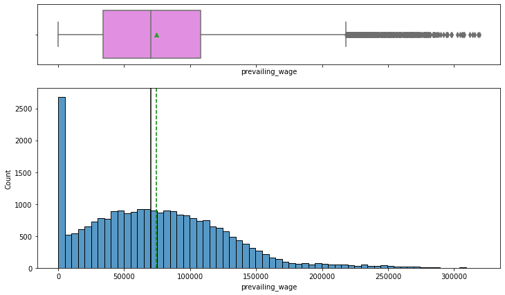

```python
#prevailing_wage
histogram_boxplot(data,'prevailing_wage')
```

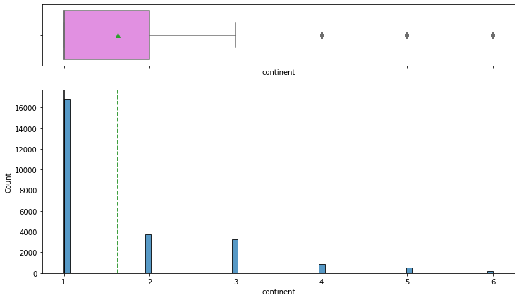

```python
#prevailing_wage
histogram_boxplot(data,'continent')
```

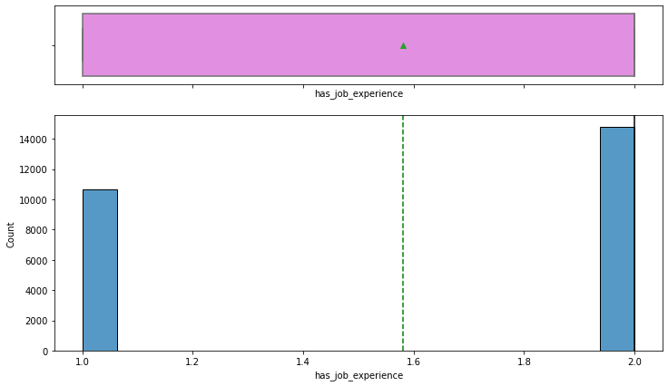

```python
#prevailing_wage
histogram_boxplot(data,'has_job_experience')
```

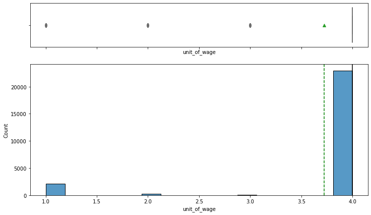

```python
#prevailing_wage
histogram_boxplot(data,'unit_of_wage')
```

```python
# function to create labeled barplots


def labeled_barplot(data, feature, perc=False, n=None):
    """
    Barplot with percentage at the top

    data: dataframe
    feature: dataframe column
    perc: whether to display percentages instead of count (default is False)
    n: displays the top n category levels (default is None, i.e., display all levels)
    """

    total = len(data[feature])  # length of the column
    count = data[feature].nunique()
    if n is None:
        plt.figure(figsize=(count + 1, 5))
    else:
        plt.figure(figsize=(n + 1, 5))

    plt.xticks(rotation=90, fontsize=15)
    ax = sns.countplot(
        data=data,
        x=feature,
        palette="Paired",
        order=data[feature].value_counts().index[:n].sort_values(),
    )

    for p in ax.patches:
        if perc == True:
            label = "{:.1f}%".format(
                100 * p.get_height() / total
            )  # percentage of each class of the category
        else:
            label = p.get_height()  # count of each level of the category

        x = p.get_x() + p.get_width() / 2  # width of the plot
        y = p.get_height()  # height of the plot

        ax.annotate(
            label,
            (x, y),
            ha="center",
            va="center",
            size=12,
            xytext=(0, 5),
            textcoords="offset points",
        )  # annotate the percentage

    plt.show()  # show the plot
```

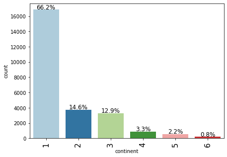

```python
labeled_barplot(data, "continent", perc=True)
```

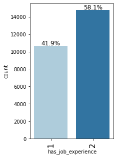

```python
labeled_barplot(data, "has_job_experience", perc=True)
```

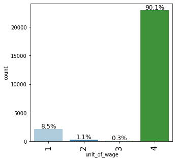

```python
labeled_barplot(data, "unit_of_wage", perc=True)
```

```python
# function to plot stacked bar chart


def stacked_barplot(data, predictor, target):
    """
    Print the category counts and plot a stacked bar chart

    data: dataframe
    predictor: independent variable
    target: target variable
    """
    count = data[predictor].nunique()
    sorter = data[target].value_counts().index[-1]
    tab1 = pd.crosstab(data[predictor], data[target], margins=True).sort_values(
        by=sorter, ascending=False
    )
    print(tab1)
    print("-" * 120)
    tab = pd.crosstab(data[predictor], data[target], normalize="index").sort_values(
        by=sorter, ascending=False
    )
    tab.plot(kind="bar", stacked=True, figsize=(count + 1, 5))
    plt.legend(
        loc="lower left",
        frameon=False,
    )
    plt.legend(loc="upper left", bbox_to_anchor=(1, 1))
    plt.show()
```

```
case_status     0      1    All
continent
All          8462  17018  25480
1            5849  11012  16861
3            1255   2037   3292
2             775   2957   3732
4             359    493    852
5             154    397    551
6              70    122    192
------------------------------------------------------------------------------------------------------------------------
```

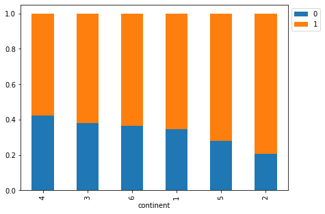

```python
stacked_barplot(data, "continent", "case_status")
```

```
case_status            0      1    All
has_job_experience
All                 8462  17018  25480
1                   4684   5994  10678
2                   3778  11024  14802
------------------------------------------------------------------------------------------------------------------------
```

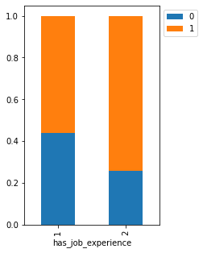

```python
stacked_barplot(data, "has_job_experience", "case_status")
```

```
case_status      0      1    All
unit_of_wage
All           8462  17018  25480
4             6915  16047  22962
1             1410    747   2157
2              103    169    272
3               34     55     89
------------------------------------------------------------------------------------------------------------------------
```

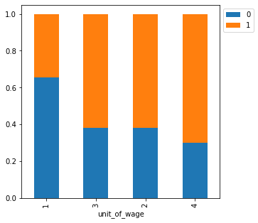

```python
stacked_barplot(data, "unit_of_wage", "case_status")
```

### Bivariate Analysis

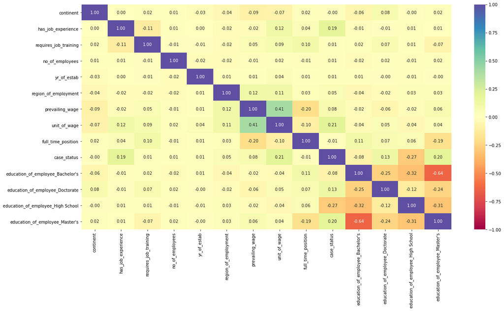

```python
plt.figure(figsize=(20,10))
sns.heatmap(data.corr(),annot=True,vmin=-1,vmax=1,fmt='.2f',cmap="Spectral")
plt.show()
```

- Two variables that are highly correlated are education of employee Bachelor's and education of employee Master's, we could drop one of these variables, or assume that even though an individual which has a master's degree usually has a bachelor's degree, but having a bachelor's degree is still valuable information to the dataset.

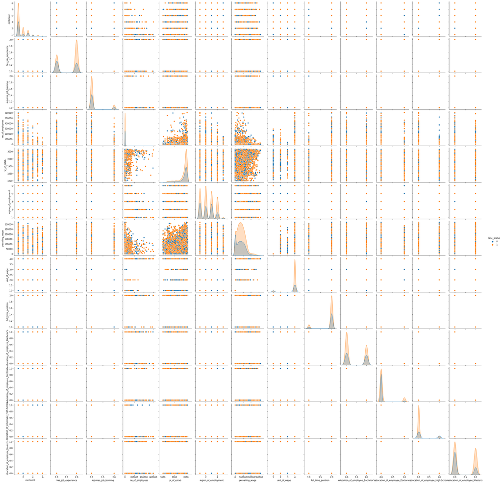

```python
sns.pairplot(data,hue='case_status')
plt.show()
```

## Data Preprocessing

- Missing value treatment (if needed)
- Feature engineering
- Outlier detection and treatment (if needed)
- Preparing data for modeling
- Any other preprocessing steps (if needed)

## Split the data into train and test sets

```python
X = data.drop("case_status" , axis=1)
y = data.pop("case_status")
```

```python
X_train, X_test, y_train, y_test = train_test_split(X, y, test_size=.30, random_state=1,stratify=y)
```

```python
## Function to create confusion matrix
def make_confusion_matrix(model,y_actual,labels=[1, 0]):
    '''
    model : classifier to predict values of X
    y_actual : ground truth

    '''
    y_predict = model.predict(X_test)
    cm=metrics.confusion_matrix( y_actual, y_predict, labels=[0, 1])
    df_cm = pd.DataFrame(cm, index = [i for i in ["Actual - No","Actual - Yes"]],
                  columns = [i for i in ['Predicted - No','Predicted - Yes']])
    group_counts = ["{0:0.0f}".format(value) for value in
                cm.flatten()]
    group_percentages = ["{0:.2%}".format(value) for value in
                         cm.flatten()/np.sum(cm)]
    labels = [f"{v1}\n{v2}" for v1, v2 in
              zip(group_counts,group_percentages)]
    labels = np.asarray(labels).reshape(2,2)
    plt.figure(figsize = (10,7))
    sns.heatmap(df_cm, annot=labels,fmt='')
    plt.ylabel('True label')
    plt.xlabel('Predicted label')
```

```python
##  Function to calculate different metric scores of the model - Accuracy, Recall and Precision
def get_metrics_score(model,flag=True):
    '''
    model : classifier to predict values of X

    '''
    # defining an empty list to store train and test results
    score_list=[]

    pred_train = model.predict(X_train)
    pred_test = model.predict(X_test)

    train_acc = model.score(X_train,y_train)
    test_acc = model.score(X_test,y_test)

    train_recall = metrics.recall_score(y_train,pred_train)
    test_recall = metrics.recall_score(y_test,pred_test)

    train_precision = metrics.precision_score(y_train,pred_train)
    test_precision = metrics.precision_score(y_test,pred_test)

    score_list.extend((train_acc,test_acc,train_recall,test_recall,train_precision,test_precision))

    # If the flag is set to True then only the following print statements will be dispayed. The default value is set to True.
    if flag == True:
        print("Accuracy on training set : ",model.score(X_train,y_train))
        print("Accuracy on test set : ",model.score(X_test,y_test))
        print("Recall on training set : ",metrics.recall_score(y_train,pred_train))
        print("Recall on test set : ",metrics.recall_score(y_test,pred_test))
        print("Precision on training set : ",metrics.precision_score(y_train,pred_train))
        print("Precision on test set : ",metrics.precision_score(y_test,pred_test))

    return score_list # returning the list with train and test scores
```

## Building bagging and boosting models

### AdaBoost Classifier

```python
abc = AdaBoostClassifier(random_state=1)
abc.fit(X_train,y_train)
```

```
AdaBoostClassifier(random_state=1)
```

```python
#Using above defined function to get accuracy, recall and precision on train and test set
abc_score=get_metrics_score(abc)
```

```
Accuracy on training set :  0.7386745907154071
Accuracy on test set :  0.7345630559916274
Recall on training set :  0.8858389994124066
Recall on test set :  0.8830558276199804
Precision on training set :  0.7617294644146095
Precision on test set :  0.7589225589225589
```

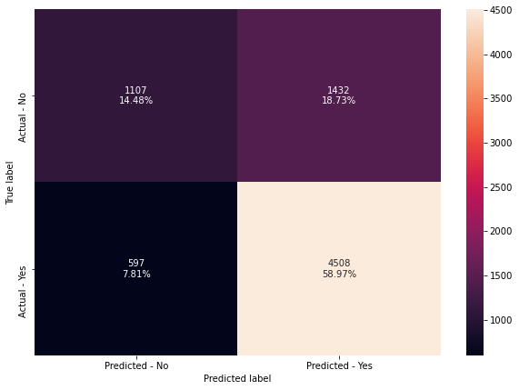

```python
make_confusion_matrix(abc,y_test)
```

### Gradient Boosting Classifier

```python
gbc = GradientBoostingClassifier(random_state=1)
gbc.fit(X_train,y_train)
```

```
GradientBoostingClassifier(random_state=1)
```

```python
#Using above defined function to get accuracy, recall and precision on train and test set
gbc_score=get_metrics_score(gbc)
```

```
Accuracy on training set :  0.7576250280331913
Accuracy on test set :  0.7429356357927787
Recall on training set :  0.893393771510115
Recall on test set :  0.8844270323212536
Precision on training set :  0.7770882009345794
Precision on test set :  0.766553480475382
```

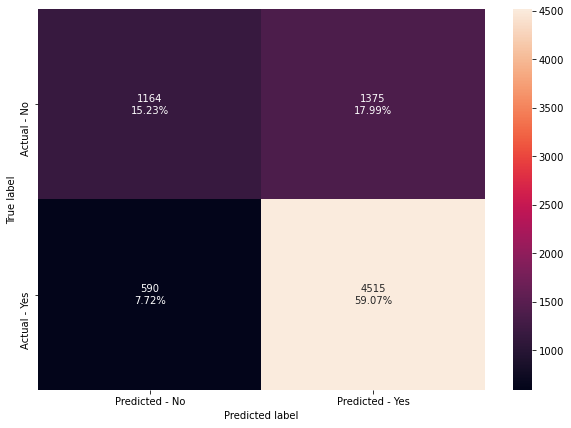

```python
make_confusion_matrix(gbc,y_test)
```

**With default parameters:**

- Of the two tests, GB has the highest accuracy, recall, and precision measures, therefore the higher performance.

### AdaBoost Classifier

```python
# Choose the type of classifier.
abc_tuned = AdaBoostClassifier(random_state=1)

# Grid of parameters to choose from
## add from article
parameters = {
    #Let's try different max_depth for base_estimator
    "base_estimator":[DecisionTreeClassifier(max_depth=1, random_state=1),DecisionTreeClassifier(max_depth=2, random_state=1),DecisionTreeClassifier(max_depth=3, random_state=1)],
    "n_estimators": np.arange(10),
    "learning_rate":np.arange(0.1)
}

# Type of scoring used to compare parameter combinations
acc_scorer = metrics.make_scorer(metrics.recall_score)

# Run the grid search
grid_obj = GridSearchCV(abc_tuned, parameters, scoring=acc_scorer,cv=5)
grid_obj = grid_obj.fit(X_train, y_train)

# Set the clf to the best combination of parameters
abc_tuned = grid_obj.best_estimator_

# Fit the best algorithm to the data.
abc_tuned.fit(X_train, y_train)
```

[output not shown]

```python
#Using above defined function to get accuracy, recall and precision on train and test set
abc_tuned_score=get_metrics_score(abc_tuned)
```

[output not shown]

```python
make_confusion_matrix(abc_tuned,y_test)
```

[output not shown]

```python
X_train.shape, X_test.shape
```

```
((17836, 13), (7644, 13))
```

```python
# function to compute adjusted R-squared
def adj_r2_score(predictors, targets, predictions):
    r2 = r2_score(targets, predictions)
    n = predictors.shape[0]
    k = predictors.shape[1]
    return 1 - ((1 - r2) * (n - 1) / (n - k - 1))


# function to compute MAPE
def mape_score(targets, predictions):
    return np.mean(np.abs(targets - predictions) / targets) * 100


# function to compute different metrics to check performance of a regression model
def model_performance_regression(model, predictors, target):
    """
    Function to compute different metrics to check regression model performance

    model: regressor
    predictors: independent variables
    target: dependent variable
    """

    # predicting using the independent variables
    pred = model.predict(predictors)

    r2 = r2_score(target, pred)  # to compute R-squared
    adjr2 = adj_r2_score(predictors, target, pred)  # to compute adjusted R-squared
    rmse = np.sqrt(mean_squared_error(target, pred))  # to compute RMSE
    mae = mean_absolute_error(target, pred)  # to compute MAE
    mape = mape_score(target, pred)  # to compute MAPE

    # creating a dataframe of metrics
    df_perf = pd.DataFrame(
        {
            "RMSE": rmse,
            "MAE": mae,
            "R-squared": r2,
            "Adj. R-squared": adjr2,
            "MAPE": mape,
        },
        index=[0],
    )

    return df_perf
```

```python
##  Function to calculate r2_score and RMSE on train and test data
def get_model_score(model, flag=True):
    '''
    model : classifier to predict values of X

    '''
    # defining an empty list to store train and test results
    score_list=[]

    pred_train = model.predict(X_train)
    pred_test = model.predict(X_test)

    train_r2=metrics.r2_score(y_train,pred_train)
    test_r2=metrics.r2_score(y_test,pred_test)
    train_rmse=np.sqrt(metrics.mean_squared_error(y_train,pred_train))
    test_rmse=np.sqrt(metrics.mean_squared_error(y_test,pred_test))

    #Adding all scores in the list
    score_list.extend((train_r2,test_r2,train_rmse,test_rmse))

    # If the flag is set to True then only the following print statements will be dispayed, the default value is True
    if flag==True:
        print("R-sqaure on training set : ",metrics.r2_score(y_train,pred_train))
        print("R-square on test set : ",metrics.r2_score(y_test,pred_test))
        print("RMSE on training set : ",np.sqrt(metrics.mean_squared_error(y_train,pred_train)))
        print("RMSE on test set : ",np.sqrt(metrics.mean_squared_error(y_test,pred_test)))

    # returning the list with train and test scores
    return score_list
```

## Decision Tree Model

```python
dtree=DecisionTreeRegressor(random_state=1)
dtree.fit(X_train,y_train)
```

```
DecisionTreeRegressor(random_state=1)
```

```python
from sklearn.metrics import r2_score, mean_squared_error, mean_absolute_error
```

```python
dtree_model_train_perf=model_performance_regression(dtree, X_train,y_train)
print("Training performance \n",dtree_model_train_perf)
```

```
Training performance
    RMSE  MAE  R-squared  Adj. R-squared  MAPE
0   0.0  0.0        1.0             1.0   0.0
```

```python
dtree_model_test_perf=model_performance_regression(dtree, X_test,y_test)
print("Testing performance \n",dtree_model_test_perf)
```

```
Testing performance
        RMSE       MAE  R-squared  Adj. R-squared  MAPE
0  0.587124  0.344715  -0.553971       -0.556618   inf
```

## Will tuning the hyperparameters improve the model performance?

```python
# Choose the type of classifier.
dtree_tuned = DecisionTreeRegressor(random_state=1)

# Grid of parameters to choose from
parameters = {'max_depth': list(np.arange(2,20)) + [None],
              'min_samples_leaf': [1, 3, 5, 7, 10],
              'max_leaf_nodes' : [2, 3, 5, 10, 15] + [None],
              'min_impurity_decrease': [0.001, 0.01, 0.1, 0.0]
             }

# Type of scoring used to compare parameter combinations
scorer = metrics.make_scorer(metrics.r2_score)

# Run the grid search
grid_obj = GridSearchCV(dtree_tuned, parameters, scoring=scorer,cv=5)
grid_obj = grid_obj.fit(X_train, y_train)

# Set the clf to the best combination of parameters
dtree_tuned = grid_obj.best_estimator_

# Fit the best algorithm to the data.
dtree_tuned.fit(X_train, y_train)
```

```
DecisionTreeRegressor(max_depth=8, max_leaf_nodes=15, random_state=1)
```

```python
dtree_tuned_model_train_perf = model_performance_regression(dtree_tuned, X_train,y_train)
print("Training performance \n",dtree_model_train_perf)
```

```
Training performance
    RMSE  MAE  R-squared  Adj. R-squared  MAPE
0   0.0  0.0        1.0             1.0   0.0
```

```python
dtree_tuned_model_test_perf = model_performance_regression(dtree_tuned, X_test,y_test)
print("Testing performance \n",dtree_tuned_model_test_perf)
```

```
Testing performance
       RMSE       MAE  R-squared  Adj. R-squared  MAPE
0  0.42606  0.359787   0.181678        0.180284   inf
```

**Plotting the feature importance of each variable**

```python
print(pd.DataFrame(dtree_tuned.feature_importances_, columns = ["Imp"], index = X_train.columns).sort_values(by = 'Imp', ascending = False))
```

```
                                        Imp
education_of_employee_High School  0.390961
has_job_experience                 0.215371
education_of_employee_Bachelor's   0.149672
prevailing_wage                    0.107158
unit_of_wage                       0.048036
continent                          0.030126
region_of_employment               0.027661
full_time_position                 0.017848
education_of_employee_Master's     0.013167
requires_job_training              0.000000
no_of_employees                    0.000000
yr_of_estab                        0.000000
education_of_employee_Doctorate    0.000000
```

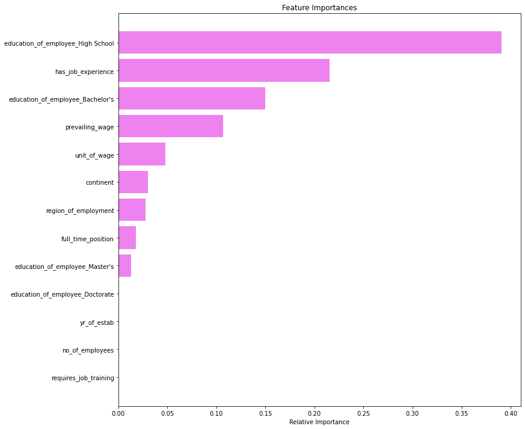

```python
feature_names = X_train.columns
importances = dtree_tuned.feature_importances_
indices = np.argsort(importances)

plt.figure(figsize=(12,12))
plt.title('Feature Importances')
plt.barh(range(len(indices)), importances[indices], color='violet', align='center')
plt.yticks(range(len(indices)), [feature_names[i] for i in indices])
plt.xlabel('Relative Importance')
plt.show()
```

## Random Forest Model

```python
rf_estimator=RandomForestRegressor(random_state=1)
rf_estimator.fit(X_train,y_train)
```

```
RandomForestRegressor(random_state=1)
```

```python
rf_estimator_model_train_perf = model_performance_regression(rf_estimator, X_train,y_train)
print("Training performance \n",rf_estimator_model_train_perf)
```

```
Training performance
        RMSE       MAE  R-squared  Adj. R-squared  MAPE
0  0.161929  0.127067   0.881783        0.881697   inf
```

```python
rf_estimator_model_test_perf = model_performance_regression(rf_estimator, X_test,y_test)
print("Testing performance \n",rf_estimator_model_test_perf)
```

```
Testing performance
        RMSE       MAE  R-squared  Adj. R-squared  MAPE
0  0.436599  0.348134   0.140693        0.139229   inf
```

### Bagging Classifier

```python
#base_estimator for bagging classifier is a decision tree by default
bagging_estimator=BaggingClassifier(random_state=1)
bagging_estimator.fit(X_train,y_train)
```

```
BaggingClassifier(random_state=1)
```

```python
#Using above defined function to get accuracy, recall and precision on train and test set
bagging_estimator_score=get_metrics_score(bagging_estimator)
```

```
Accuracy on training set :  0.9843014128728415
Accuracy on test set :  0.6908686551543695
Recall on training set :  0.98497439771678
Recall on test set :  0.7649363369245837
Precision on training set :  0.9914659907055344
Precision on test set :  0.7705209155485399
```

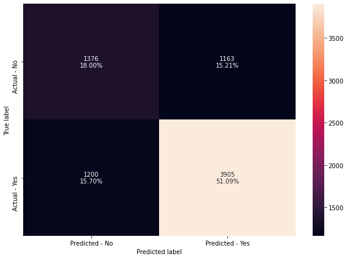

```python
make_confusion_matrix(bagging_estimator,y_test)
```

### Random Forest Classifier

```python
#Train the random forest classifier
rf_estimator=RandomForestClassifier(random_state=1)
rf_estimator.fit(X_train,y_train)
```

```
RandomForestClassifier(random_state=1)
```

```python
#Using above defined function to get accuracy, recall and precision on train and test set
rf_estimator_score=get_metrics_score(rf_estimator)
```

```
Accuracy on training set :  1.0
Accuracy on test set :  0.7251439037153323
Recall on training set :  1.0
Recall on test set :  0.8423114593535749
Precision on training set :  1.0
Precision on test set :  0.7684060042887777
```

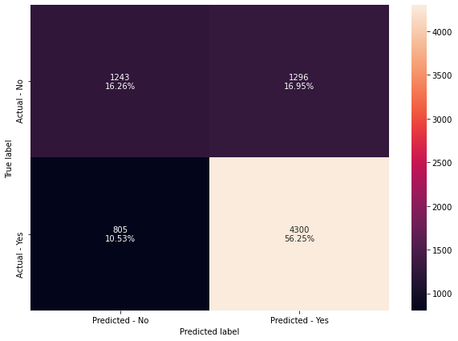

```python
make_confusion_matrix(rf_estimator,y_test)
```